# Practical Machine Learning Course Project

Pablo Arias

Thursday, January 08, 2015

## Prompt

Analysis will be done of accelerometer data on the belt, forearm, arm, and dumbbell of 6 participants while they were asked to perform dumbbell lifts correctly(A) and incorrectly(B-E) in 5 different ways, to generate a predictive model to detects what class (A-E) of exercise is being done.

The analysis will be done with the data collected for the following paper [Qualitative Activity Recognition of Weight Lifting Exercises](http://groupware.les.inf.puc-rio.br/public/papers/2013.Velloso.QAR-WLE.pdf) by authors: *Velloso, E.; Bulling, A.; Gellersen, H.; Ugulino, W.; Fuks, H.* as part of the Proceedings of 4th International Conference in Cooperation with SIGCHI (Augmented Human ’13) . Stuttgart, Germany: ACM SIGCHI, 2013, found here:

https://d396qusza40orc.cloudfront.net/predmachlearn/pml-training.csv https://d396qusza40orc.cloudfront.net/predmachlearn/pml-testing.csv

Read more about this paper here

## Data Procesisng

According to the [paper](http://groupware.les.inf.puc-rio.br/public/papers/2013.Velloso.QAR-WLE.pdf), the data has measurements for 4 accelerator sensors: dumbbell, arm, forearm and belt. The measurements were taken with the sliding window approach with different lengths from 0.5 second to 2.5 seconds, with 0.5 second overlap. In each step of the sliding window the features were calculated for the Euler angles (roll, pitch, yaw), as well as the raw accelerometer, gyroscope and magnetometer readings. For the Euler angles of each of the four sensors eight features were calculated: mean, variance, standard deviation, max, min, amplitude, kurtosis and skewness. Two additional calculated features are present: The total acceleration for all the sensors and its variance, generating in total 38 features per sensor and two additional global features.

### Data completeness

Since we are building a predictor that needs to be validated against a predefined test set, the test set should include values for our predictors. It seems that because the calculation for some features was done at the end of a sampling window, the testing sample does not contain these features, so they will not be used as predictors. These features are: kurtosis, skewness, max, min, amplitude, mean, standard deviation, variance and the variance of total acceleration.

```r
library(caret)
```

```r
library(ggplot2)

setwd("~/Coursera/8_MachineL")
train_dat <- read.csv("data/pml-training.csv", na.strings=c("NA",""))
test_dat <- read.csv("data/pml-testing.csv", na.strings=c("NA",""))

# Eliminate columns that have no value in the test set
emptyCols <- lapply(test_dat, function(x) sum(is.na(x)/length(x)))==1
test_dat <- test_dat[!emptyCols]
train_dat <- train_dat[!emptyCols]
test_dat <- test_dat[, grep("user_name|_belt|_arm|_forearm|_dumbbell", names(test_dat))]
train_dat <- train_dat[, grep("user_name|_belt|_arm|_forearm|_dumbbell|class", names(train_dat))]
```

We end up with 13 variables for each sensor. These are the ones for the belt sensor as an example:

```r
names(train_dat)[grep("_belt", names(train_dat))]
```

```
##  [1] "roll_belt"        "pitch_belt"       "yaw_belt"
##  [4] "total_accel_belt" "gyros_belt_x"     "gyros_belt_y"
##  [7] "gyros_belt_z"     "accel_belt_x"     "accel_belt_y"
## [10] "accel_belt_z"     "magnet_belt_x"    "magnet_belt_y"
## [13] "magnet_belt_z"
```

### Preprocessing

We can do a quick near zero covariates check on our training set

```r
nZV <- nearZeroVar(train_dat, saveMetrics=TRUE)
any(nZV$nzv)
```

```
## [1] FALSE
```

There are no features with near zero variability, so no need to eliminate any feature for this reason.

We can also check the frequency distribution of the outcome variable to make sure that we have an even distribution among all the classification groups and a good representation among the 6 users that participated in the study.

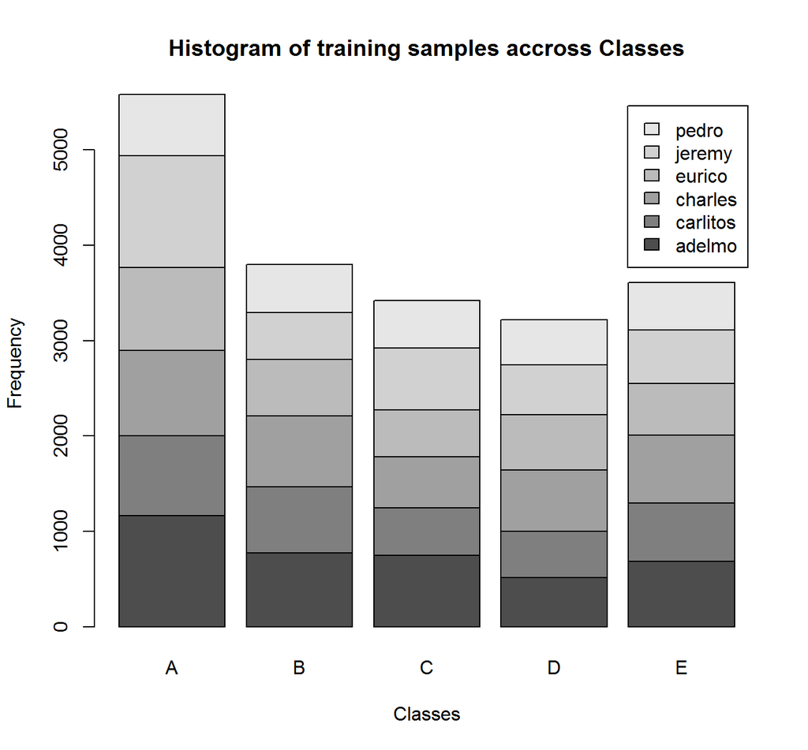

```r
table_dat <- table(train_dat$user_name,train_dat$classe)
barplot(table_dat, main = "Histogram of training samples accross Classes",
        xlab = "Classes", ylab = "Frequency", legend=TRUE)
```

We can see we have sufficient distribution of samples across classes

## Prediction Model Approach

We will try three prediction approaches, cross-validate and compare different attributes (training, prediction times and accuracy) of the models.

1. A Random Forest model with all but *user_name* predictors. This model is expected to be expensive in terms of training and prediction times because of the amount of predictors. We exclude *user_name* because we want the model to predict the class of exercise when the exercise is done by any user other than the 6 that participated in the research.
2. Use the top 10 predictors from model 1 and fit a new Random Forest only with those predictors. This model will be worst in training time because (to be fair) it should include the training time of model 1 plus model 2 and most likely will be less accurate because it does not have the contribution of the other predictors. It should predict faster.
3. The third model will use the best model between model 1 and model 2 and include the *user_name* feature. This model is expected to have a higher out of sample accuracy because the variability between 6 users can be used to better predict the outcome.

We will split the training data into three equally sized sets for each of the three models, using random sampling technique. Each of these sets, will be split into a training (80%) and test(20%) sets.

```r
set.seed(211069)
sub <- list()                   # List of three bid sub groups of data
mod <- list()                   # List of the 3 models
mod_train_time <- list()        # List of training times
pred <- list()                  # List of 3 predicted data
mod_pred_time <- list()         # List of the 3 prediction times
confMat <- list()               # List of the three Confusion Matrices
accuracy <- list()              # List of the three overall accuracy
train <- list()                 # List of each of the train set
test <- list()                  # List of each of the test sets
confusion <- list()             # List of confusion matrix table for plotting

sub_set_index <- createDataPartition(y=train_dat$classe, p=(1/3), list=FALSE)
sub[[1]] <- train_dat[sub_set_index, -1] # Exclude user_name
rest <- train_dat[-sub_set_index, ]
sub_set_index <- createDataPartition(y=rest$classe, p=.5, list=FALSE)
sub[[2]] <- rest[sub_set_index, -1] # Exclude user_name
sub[[3]] <- rest[-sub_set_index,]

index <- createDataPartition(y=sub[[1]]$classe, p=.8, list=FALSE)
train[[1]] <- sub[[1]][index,]
test[[1]] <- sub[[1]][-index,]

index <- createDataPartition(y=sub[[2]]$classe, p=.8, list=FALSE)
train[[2]] <- sub[[2]][index,]
test[[2]] <- sub[[2]][-index,]

index <- createDataPartition(y=sub[[3]]$classe, p=.8, list=FALSE)
train[[3]] <- sub[[3]][index,]
test[[3]] <-sub[[3]][-index,]
```

We can verify the dimension of the three data sets

```r
lapply(sub, dim)
```

```
## [[1]]
## [1] 6542   53
##
## [[2]]
## [1] 6541   53
##
## [[3]]
## [1] 6539   54
```

```r
lapply(train, dim)
```

```
## [[1]]
## [1] 5235   53
##
## [[2]]
## [1] 5234   53
##
## [[3]]
## [1] 5232   54
```

```r
lapply(test, dim)
```

```
## [[1]]
## [1] 1307   53
##
## [[2]]
## [1] 1307   53
##
## [[3]]
## [1] 1307   54
```

Again we can check the frequency distribution of the outcome variable to make sure that we have an even distribution among all the classification groups for the three model datasets

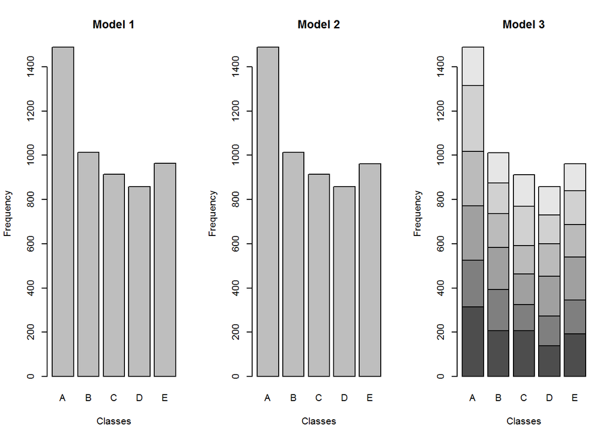

```r
par(mfrow=c(1,3))

plot(train[[1]]$classe, main = "Model 1",
     xlab = "Classes", ylab = "Frequency")
plot(train[[2]]$classe, main = "Model 2",
     xlab = "Classes", ylab = "Frequency")
table_dat <- table(train[[3]]$user_name,train[[3]]$classe)
barplot(table_dat, main = "Model 3",
     xlab = "Classes", ylab = "Frequency")
```

The random samppling is doing its work, since the frequency remained the same across all sets.

#### Random forest model with all but *user_name* predictors

Train model one by splitting into a training a test set. Use training set to train and test set to calculate out of sample accuracy. Time to train the model and to predict will be measured. Will use an odd number of 3 for the k-fold of the random forest.

```r
set.seed(211069)
mod_train_time[[1]] <- system.time(mod[[1]] <- train(classe ~ ., data=train[[1]], method="rf",
                                           trControl=trainControl(method = "cv", number = 3)))
mod_train_time[[1]]
```

```
##    user  system elapsed
##  145.03    1.05  147.02
```

We can now predict against the test set, show accuracy with test set and plot a confusion matrix

```r
mod_pred_time[[1]] <- system.time(pred[[1]] <- predict(mod[[1]], newdata=test[[1]]))
mod_pred_time[[1]]
```

```
##    user  system elapsed
##    0.09    0.00    0.09
```

```r
confMat[[1]] <- confusionMatrix(pred[[1]], test[[1]]$classe)
confMat[[1]]
```

```
## Confusion Matrix and Statistics
##
##           Reference
## Prediction   A   B   C   D   E
##          A 369   3   0   0   0
##          B   2 248   5   0   2
##          C   1   2 220   7   0
##          D   0   0   3 206   3
##          E   0   0   0   1 235
##
## Overall Statistics
##
##                Accuracy : 0.9778
##                  95% CI : (0.9683, 0.9851)
##     No Information Rate : 0.2846
##     P-Value [Acc > NIR] : < 2.2e-16
##
##                   Kappa : 0.9719
##  Mcnemar's Test P-Value : NA
##
## Statistics by Class:
##
##                      Class: A Class: B Class: C Class: D Class: E
## Sensitivity            0.9919   0.9802   0.9649   0.9626   0.9792
## Specificity            0.9968   0.9915   0.9907   0.9945   0.9991
## Pos Pred Value         0.9919   0.9650   0.9565   0.9717   0.9958
## Neg Pred Value         0.9968   0.9952   0.9926   0.9927   0.9953
## Prevalence             0.2846   0.1936   0.1744   0.1637   0.1836
## Detection Rate         0.2823   0.1897   0.1683   0.1576   0.1798
## Detection Prevalence   0.2846   0.1966   0.1760   0.1622   0.1806
## Balanced Accuracy      0.9944   0.9858   0.9778   0.9786   0.9891
```

```r
accuracy[[1]] <- confMat[[1]]$overall[1]
accuracy[[1]]
```

```
##  Accuracy
## 0.9778118
```

```r
confusion[[1]] <- as.data.frame(confMat[[1]]$table)

p1 <- ggplot(confusion[[1]], aes(Reference, Prediction, group=Prediction)) +
        ggtitle("Confusion Matrix Model 1") +
        geom_tile(aes(fill = Freq)) +
        geom_text(aes(fill = Freq, label = Freq)) +
        scale_fill_gradient(low = "white", high = "blue")
```

The accuracy of the out-of-sample set of 0.98 is high. We will later compare the training and prediction times with the other models.

The out-of-sample sensitivity and specificity for all the classes are really high. This seems to be a good predictor.

#### Random forest model with top 10 predictors from Model 1

We can use `varImp()` function to select the top 10 predictors of model 1 and again build a prediction model with those parameters only. Need to define a function so I can measure the total prediction time including all the calculations.

```r
set.seed(211069)

model2func <- function() {
        varImplist <- varImp(mod[[1]])
        varlist <- head(sort(varImplist$importance[,1], decreasing=TRUE), 10)
        newfeatures <<- rownames(varImplist$importance)[head(order(varImplist$importance,
                                                                  decreasing = T), 10)]
        mod[[2]] <<- train(classe ~ ., data=train[[2]][, c(newfeatures, "classe")],
                        method="rf", trControl=trainControl(method = "cv", number = 3))
}

mod_train_time[[2]] <- system.time(model2func())
mod_train_time[[2]]
```

```
##    user  system elapsed
##   35.55    0.97   36.66
```

With only the top 10 predictors:

```r
newfeatures
```

```
##  [1] "roll_belt"         "pitch_forearm"     "roll_forearm"
##  [4] "yaw_belt"          "magnet_dumbbell_y" "magnet_dumbbell_z"
##  [7] "pitch_belt"        "accel_dumbbell_y"  "roll_dumbbell"
## [10] "accel_forearm_x"
```

```r
mod_pred_time[[2]] <- system.time(pred[[2]] <- predict(mod[[2]], newdata=test[[2]][, c(newfeatures, "classe")]))
mod_pred_time[[2]]
```

```
##    user  system elapsed
##    0.10    0.01    0.12
```

```r
confMat[[2]] <- confusionMatrix(pred[[2]], test[[2]]$classe)
confMat[[2]]
```

```
## Confusion Matrix and Statistics
##
##           Reference
## Prediction   A   B   C   D   E
##          A 366   6   0   1   0
##          B   3 240   3   4   4
##          C   3   4 224   8   1
##          D   0   0   1 201   1
##          E   0   3   0   0 234
##
## Overall Statistics
##
##                Accuracy : 0.9679
##                  95% CI : (0.9568, 0.9767)
##     No Information Rate : 0.2846
##     P-Value [Acc > NIR] : < 2.2e-16
##
##                   Kappa : 0.9593
##  Mcnemar's Test P-Value : NA
##
## Statistics by Class:
##
##                      Class: A Class: B Class: C Class: D Class: E
## Sensitivity            0.9839   0.9486   0.9825   0.9393   0.9750
## Specificity            0.9925   0.9867   0.9852   0.9982   0.9972
## Pos Pred Value         0.9812   0.9449   0.9333   0.9901   0.9873
## Neg Pred Value         0.9936   0.9877   0.9963   0.9882   0.9944
## Prevalence             0.2846   0.1936   0.1744   0.1637   0.1836
## Detection Rate         0.2800   0.1836   0.1714   0.1538   0.1790
## Detection Prevalence   0.2854   0.1943   0.1836   0.1553   0.1813
## Balanced Accuracy      0.9882   0.9677   0.9838   0.9687   0.9861
```

```r
accuracy[[2]] <- confMat[[2]]$overall[1]
accuracy[[2]]
```

```
##  Accuracy
## 0.9678653
```

```r
confusion[[2]] <- as.data.frame(confMat[[2]]$table)

p2 <- ggplot(confusion[[2]], aes(Reference, Prediction, group=Prediction)) +
        ggtitle("Confusion Matrix Model 2") +
        geom_tile(aes(fill = Freq)) +
        geom_text(aes(fill = Freq, label = Freq)) +
        scale_fill_gradient(low = "white", high = "blue")

accuracy_diff12 <- round((accuracy[[1]]-accuracy[[2]])*100/accuracy[[1]],2)
```

This model does not predict faster than model 1, or it is within the measuring error. It is 1.02% less accurate. Significantly slower to train, no measureable performance improvement with a slight loss of accuracy.

#### Random forest with all predictors

For this third model we will include the *user_name* feature as a predictor

```r
set.seed(211069)
mod_train_time[[3]] <- system.time(mod[[3]] <- train(classe ~ ., data=train[[3]],
                                           method="rf",
                                           trControl=trainControl(method = "cv", number = 3)))
mod_train_time[[3]]
```

```
##    user  system elapsed
##  161.91    1.11  164.14
```

```r
mod_pred_time[[3]] <- system.time(pred[[3]] <- predict(mod[[3]], newdata=test[[3]]))
mod_pred_time[[3]]
```

```
##    user  system elapsed
##    0.09    0.00    0.09
```

```r
confMat[[3]] <- confusionMatrix(pred[[3]], test[[3]]$classe)

confMat[[3]]
```

```
## Confusion Matrix and Statistics
##
##           Reference
## Prediction   A   B   C   D   E
##          A 370   2   0   0   0
##          B   2 249   3   0   0
##          C   0   2 223   8   0
##          D   0   0   2 205   4
##          E   0   0   0   1 236
##
## Overall Statistics
##
##                Accuracy : 0.9816
##                  95% CI : (0.9728, 0.9882)
##     No Information Rate : 0.2846
##     P-Value [Acc > NIR] : < 2.2e-16
##
##                   Kappa : 0.9768
##  Mcnemar's Test P-Value : NA
##
## Statistics by Class:
##
##                      Class: A Class: B Class: C Class: D Class: E
## Sensitivity            0.9946   0.9842   0.9781   0.9579   0.9833
## Specificity            0.9979   0.9953   0.9907   0.9945   0.9991
## Pos Pred Value         0.9946   0.9803   0.9571   0.9716   0.9958
## Neg Pred Value         0.9979   0.9962   0.9953   0.9918   0.9963
## Prevalence             0.2846   0.1936   0.1744   0.1637   0.1836
## Detection Rate         0.2831   0.1905   0.1706   0.1568   0.1806
## Detection Prevalence   0.2846   0.1943   0.1783   0.1614   0.1813
## Balanced Accuracy      0.9962   0.9897   0.9844   0.9762   0.9912
```

```r
accuracy[[3]] <- confMat[[3]]$overall[1]
accuracy[[3]]
```

```
##  Accuracy
## 0.9816373
```

```r
confusion[[3]] <- as.data.frame(confMat[[3]]$table)

p3 <- ggplot(confusion[[3]], aes(Reference, Prediction, group=Prediction)) +
        ggtitle("Confusion Matrix Model 3") +
        geom_tile(aes(fill = Freq)) +
        geom_text(aes(fill = Freq, label = Freq)) +
        scale_fill_gradient(low = "white", high = "blue")

pred_time_diff13 <- round((mod_pred_time[[3]][3]-mod_pred_time[[1]][3])*100/mod_pred_time[[1]][3],2)

accuracy_diff13 <- round((accuracy[[3]]-accuracy[[1]])*100/accuracy[[1]],2)
```

As expected this model is more accurate than model 1, but only by 0.39% and no measureable penalty time to predict. And because of the added feature it also takes longer to train. Figure below shows plots for the three confusion matrices.

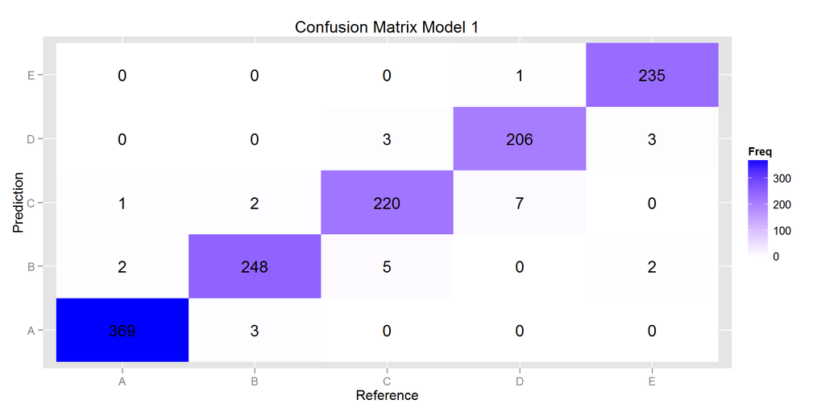

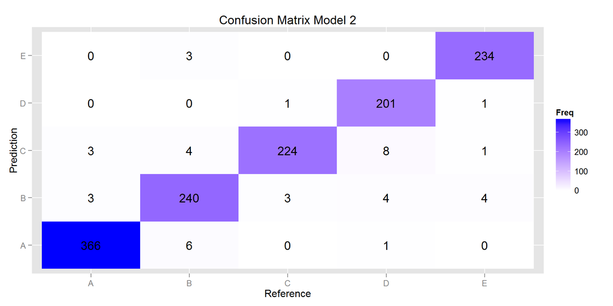

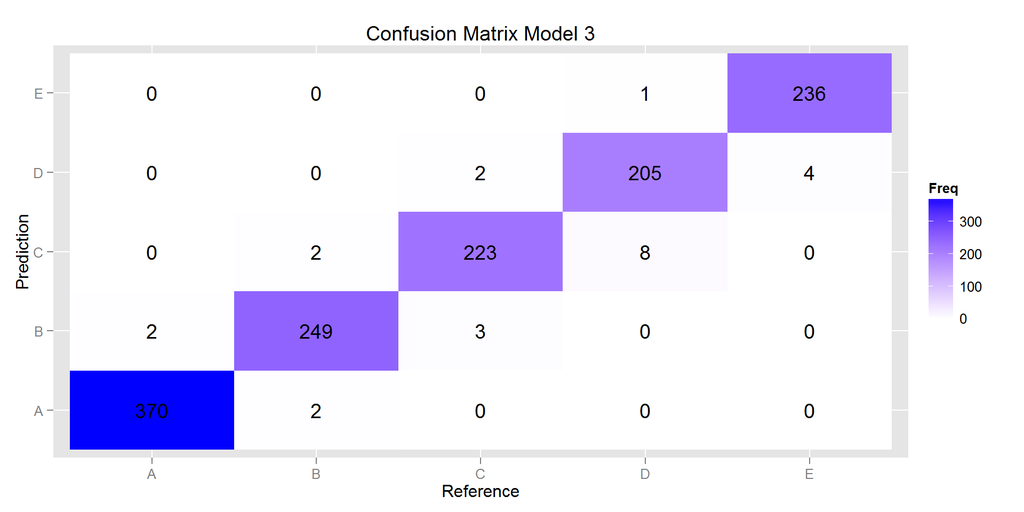

## Conclusion

Even though model 3 is the most accurate, it is just slight more accurate. We will choose model 1 as our best performer. Model 3 does not reflect the original intent of the research, but will be submitted as the second option.

We will now predict with the original 20 test samples and generate answer files with both models

```r
answers1 <- predict(mod[[1]], newdata = test_dat[,-1])
answers2 <- predict(mod[[3]], newdata = test_dat[,])

pml_write_files = function(x){
  n = length(x)
  for(i in 1:n){
    filename = paste0("problem_id_",i,".txt")
    write.table(x[i],file=filename,quote=FALSE,row.names=FALSE,col.names=FALSE)
  }
}

setwd("c:/Users/PArias/Documents/Coursera/8_MachineL/answers1/")
pml_write_files(answers1)
setwd("c:/Users/PArias/Documents/Coursera/8_MachineL/answers2/")
pml_write_files(answers2)
```